# Merged Functions

### `round()`

#### Alexander Looi

This function is used to “round” the under of significant digits in a numeric variable. It generally takes two arguments, the variable to be rounded and the number of digits to “round off”. If no digits are given the function removes all decimals.

```r
a = runif(10, 0, 20)
round(a)
```

```
##  [1] 12  1  9 16 12  6 20 10 14 15
```

```r
# round off 3 digits
round(a, digits = 3)
```

```
##  [1] 12.004  0.799  9.475 15.539 11.597  6.440 19.868  9.925 13.629 14.758
```

```r
# It cannot take strings even if they are numbers
# round(as.character(a)) # can't be done

# also will not work
words = c('cat', 'dog', 'hat', 23.555)
# round(words)
```

### `rownames`

#### Melanie R. Kazenel

The `rownames` function can be used to specify or obtain the names associated with rows in a matrix or matrix-like object. The function’s input is a matrix-like R object, and the names associated with each row are the output. The arguments “do.NULL” and “prefix” can be added; see the example below for an explanation of how to use these arguments.

```r
# The following matrix does not have row names assigned to it
z <- matrix(data = c(1:8), nrow = 4, ncol = 2)
print(z)
```

```
##      [,1] [,2]
## [1,]    1    5
## [2,]    2    6
## [3,]    3    7
## [4,]    4    8
```

```r
rownames(z) # under default settings, the output of 'rownames' is NULL when no row names have been assigned
```

[output not shown]

```r
rownames(z, do.NULL = FALSE) # when do.NULL = FALSE, names are assigned to each row using the prefix "row" plus a number
```

```
## [1] "row1" "row2" "row3" "row4"
```

```r
rownames(z, do.NULL = FALSE, prefix = "specialname") # the prefix argument can be added to specify that a name other than "row" should be added before each number when do.NULL = FALSE
```

```
## [1] "specialname1" "specialname2" "specialname3" "specialname4"
```

```r
# Assign row names to the matrix
rownames(z) <- c("kale", "broccoli", "cabbage", "brussels sprouts") # assign row names to the matrix
print(z)
```

```
##                  [,1] [,2]
## kale                1    5
## broccoli            2    6
## cabbage             3    7
## brussels sprouts    4    8
```

```r
rownames(z) # obtain the row names associated with the matrix
```

```
## [1] "kale"             "broccoli"         "cabbage"
## [4] "brussels sprouts"
```

### `sample`

#### Samantha Alger

sample() will take a random sample of a specified size. You can specify whether to sample with or without replacement.

sample(x, size, replace =FALSE)

- x - object to be sampled
- size - size of the sample
- replace - should sampling be with replacement?

```r
#create an object to sample
x <- runif(1:10)

# take a sample of 100 from x
# without replacement (we will never find duplicates)
sample(x, 4, replace = FALSE)
```

```
## [1] 0.0790970 0.7545179 0.3663761 0.7481242
```

```r
# if you sample with replacement, you can sample at a size larger than the original object
#in this case, there will be numbers repeated
sample(x, 11, replace = TRUE)
```

```
##  [1] 0.0790970 0.9169217 0.4453595 0.4414792 0.7545179 0.4453595 0.7481242
##  [8] 0.4414792 0.9076130 0.0790970 0.9076130
```

### `save`

#### April D. Makukhov

This functions allows the user to save objects in R into an external Rdata file that can then be used later in R via functions such as ‘load’ or ‘attach’. save.image() is an extension or shortcut of the ‘save’ function that allows the use to save the current workspace in R to be able to load it back in later. Basically, if you want to save a set of specific R objects in your code or to save your workspace, this is one way to do so.

```r
x <- runif(10)
z <- list(a=1, b=2, c=TRUE, d=FALSE, e = "turtle")
save(x, z, file = "Example.RData")

# now, if you clear your R environment with the little broom icon, and use the following code below to load in your Rdata file, you can go back to using the variables you used before, x and z, without having to re-run script. Essentially, the save function is saving your R environment.

load("Example.RData")
x
```

```
##  [1] 0.130109230 0.960689858 0.259571558 0.009066601 0.992870629
##  [6] 0.652903802 0.724484820 0.714281988 0.825024178 0.148244921
```

```r
z
```

```
## $a
## [1] 1
##
## $b
## [1] 2
##
## $c
## [1] TRUE
##
## $d
## [1] FALSE
##
## $e
## [1] "turtle"
```

### `saveRDS()`

#### Alexander Looi

This function allows the user to save text representations of objects they have created in R. These objects range from data frames, vectors, to linear models. These objects are saved directly to the current directory and do not need an extension to be saved (or later read by readRDS). The beauty of this function is that these saved objects can then be read in later and should still retain all of their original features. The two variables necessary to use this function are an R object, and a name for the file in the form of a character string. Additionally, you can specify if the user wants the object to be written in ascii format (a text format that is readable by most text editors). The user can specify version of R for the file to saved under (Do not save in versions < 2.0). The user can also compress the file to ‘gzip’, ‘bzip2’, or ‘xz’.

```r
y = runif(100)
x = 1:100

my_lm = lm(x ~ y)

saveRDS(my_lm, file = 'My_saveRDS')
list.files(pattern = 'My_saveRDS') # it should appear in the directory
```

```
## [1] "My_saveRDS"
```

```r
my_lm_returned = readRDS('My_saveRDS')
my_lm
```

```
##
## Call:
## lm(formula = x ~ y)
##
## Coefficients:
## (Intercept)            y
##       57.79       -14.16
```

```r
my_lm_returned
```

```
##
## Call:
## lm(formula = x ~ y)
##
## Coefficients:
## (Intercept)            y
##       57.79       -14.16
```

```r
# can save data frames
MY_DF = data.frame(y, x)
saveRDS(MY_DF, file = 'My_DF')
readRDS('My_DF')
```

```
##               y   x
## 1   0.675003473   1
## 2   0.846872858   2
## 3   0.992584993   3
## 4   0.304093186   4
## 5   0.145394889   5
## 6   0.519036944   6
## 7   0.832152318   7
## 8   0.918171508   8
## 9   0.348103863   9
## 10  0.332689337  10
## 11  0.838867004  11
## 12  0.446239590  12
## 13  0.694593564  13
## 14  0.902810826  14
```

[output cut: 86 more lines]

### `sd`

#### Emily Mikucki

The `sd` function computes the standard deviation of the numeric vector x. You can use this for a vector you create in the console (i.e. using c()) or you can get the standard deviation of a variable you have defined in a csv file. The default settings are sd(x, na.rm = FALSE) where na.rm removes the NAs.

```r
x <- c(179,160,136,227) #define your vector
sd(x) #equals 38.57892 using the R function
```

```
## [1] 38.57892
```

```r
#If you're curious, this is the formula that is being used
n <- length(x)
sd1 <-sqrt(sum((x - mean(x))^2) / (n - 1))
sd1 #sd is still 38.57892
```

```
## [1] 38.57892
```

### `Seq`

#### Erin L. Keller

Seq is the function for sequence generation and is a standard generic function. The arguments needed for this function are: * from, to - indicate what the starting and ending values of the sequence should be * by - the increment of the sequence (default = 1) * length.out - optional, the desired length of the sequence * along.with - takes the length from the length * : - can be used to create sequences of sequential numbers

The ouput for this function is a integer or double vector containing the desired sequence.

```r
Sequence <-seq(c(1:10,20:30,40:50)) # multiple sequences can be concatenated together to form one sequence
print(Sequence)
```

```
##  [1]  1  2  3  4  5  6  7  8  9 10 11 12 13 14 15 16 17 18 19 20 21 22 23
## [24] 24 25 26 27 28 29 30 31 32
```

### `seq_along`

#### Matthias Nevins

seq_along generates regular sequences. seq_along(x) takes a vector for x, and it creates a sequence upto the count of elements in the vector. seq() acts like seq_along() except when passed a vector of length 1, in which case it acts like seq_len().

```r
# EXAMPLE
a <- c(8, 9, 10)
b <- c(9, 10)
c <- 10

seq_along(a)
```

```
## [1] 1 2 3
```

```r
seq_along(b)
```

```
## [1] 1 2
```

```r
seq_along(c)
```

```
## [1] 1
```

```r
# Compared to the seq() function

seq(a)
```

```
## [1] 1 2 3
```

```r
seq(b)
```

```
## [1] 1 2
```

```r
seq(c)
```

```
##  [1]  1  2  3  4  5  6  7  8  9 10
```

### `seq_len`

#### Erin L. Keller

Seq_len is a seqeunce generator that outputs a sequence of values from 1 to the value specified in the parentheses and is equivalent to seq(length.out=). Sequence length will automatically be inferred if the start and end values are given in the seq function (i.e. seq(from=1, to=20), sequence length will be 20). It is important to note that all numerical inputs should be finite.

```r
a<-seq_len(10)
b<-seq_len(0)
print(a)
```

```
##  [1]  1  2  3  4  5  6  7  8  9 10
```

```r
print(b)
```

```
## integer(0)
```

### `setdiff`

#### Morgan W. Southgate

The setdiff function is a set function which compares two sets of values and returns the values which are in the first set but NOT in the second set. Therefore, setdiff(x, y) returns a different output than setdiff(y, x).

setdiff(x, y)

Input:  
- x, y: vectors (of the same mode) containing a sequence of items with no duplicate values.  
Output:  
- The values in the first set of values which are NOT in the second set of values.

```r
# Create two sets of values set1 and set2 with overlapping but distinct values
set1 <- c( "a","b","d","e")
set2 <- c( "a","c","d","f")

# Use the setdiff function to return the values which are unique to set1
setdiff(set1,set2)
```

```
## [1] "b" "e"
```

```r
# See that the output is changed by reversing the order of sets 1 and 2
setdiff(set2,set1)
```

```
## [1] "c" "f"
```

### `setequal`

#### Samantha Alger

setequal() tests if two vectors are equal. The function will return a logical response: (TRUE or FALSE).

```r
#create two different vectors using the sample function that will randomly sample 10 numbers from 1 to 100.
x <- sample(1:100, size=10)
y <- sample(1:100, size=10)

#use setequal to check if the two vectors are the same. since we are using the sample function, we are randomly sampling and so the two vectors will be different. setequal returns a FALSE value.
setequal(x,y)
```

```
## [1] FALSE
```

```r
#another example:
birds <- rep_len(c("finch","thrush","warbler"),20)
birds2 <- rep_len(c("NA","thrush","warbler"),20)

#using setequal returns a FALSE value because there is one value different
setequal(birds,birds2)
```

```
## [1] FALSE
```

### `sign`

#### Lauren Ashlock

This function returns a vector with signs of the corresponding elements of a variable. The output gives you 1 for positive values, 0, or -1 for negative values. The only argument for this function is a numeric vector

```r
MyVec <- c(0, 2, 5, 7, -1, -4, -7, 0, 5, -4)
sign(MyVec)
```

```
##  [1]  0  1  1  1 -1 -1 -1  0  1 -1
```

### `signif`

#### Samantha Alger

signif(x, digits=y) rounds a number (x) to a specified number of significant digits (y)

```r
signif(7.462527,digits=4)
```

```
## [1] 7.463
```

### `sin()`

#### Alexander Looi

This is the trig-function sine. It takes in any numeric type variable and outputs a numeric type. The default “x” or input of this function are radians. To input degrees the user must convert radians to degrees.

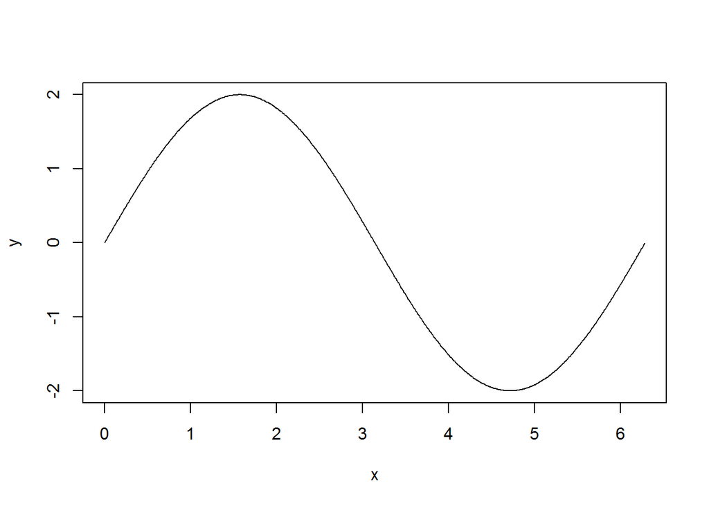

```r
x = seq(0, 2*pi, 0.01)
y = 2*sin(x)

# let's do the wave!
plot(x, y, type = 'l')
```

The `sink` function directs R output to an external source like a text file. To use `sink`, you should make a new .txt file and upload it to your working directory/R Project. This acts as your “file” argument. You might run into the arguments `append` and `split`. The default settings include append=FALSE and split=FALSE. The `append` option controls whether output overwrites or adds to a file. The `split` option determines if output is also sent to the screen as well as the output file. Note, `sink` will NOT redirect graphic ouputs (.jpg, .png, etc.).

```r
sink("TEST.txt") #Here you upload that external file you have synched to your working directory/project
i <- 1:10 #Here you create functions, data, etc. that you want to send to that external file.
outer(i, i, "*") #This was just used to format the data in the file
```

```
##       [,1] [,2] [,3] [,4] [,5] [,6] [,7] [,8] [,9] [,10]
##  [1,]    1    2    3    4    5    6    7    8    9    10
##  [2,]    2    4    6    8   10   12   14   16   18    20
##  [3,]    3    6    9   12   15   18   21   24   27    30
##  [4,]    4    8   12   16   20   24   28   32   36    40
##  [5,]    5   10   15   20   25   30   35   40   45    50
##  [6,]    6   12   18   24   30   36   42   48   54    60
##  [7,]    7   14   21   28   35   42   49   56   63    70
##  [8,]    8   16   24   32   40   48   56   64   72    80
##  [9,]    9   18   27   36   45   54   63   72   81    90
## [10,]   10   20   30   40   50   60   70   80   90   100
```

```r
sink() #This function must be used to finish the sinking/synching process!
#Now if you open up TEST.txt outside of R, it will have all of the information that you directed to it.

sink("TEST.txt", append=FALSE, split=FALSE)
sink()
#Now all of that information is gone from the .txt file.
```

### `split`

#### Emily Mikucki

The `split` function divides the data in a vector x into the groups defined by f. Basically it divides data into groups and then reassembles it The default setting is split(x, f, drop = FALSE, …). “x” can be a vector or data frame. “f” is a factor (in terms of “as.factor”) and defines the grouping from the split. “drop” is logical and indicates if levels that do not occur should be dropped (if f is a factor or a list).

```r
#A simple example
A <- c(1,2,3,4)
B <- c("X","Y","X","Y")
sp <- split(A,B)
sp$X #see data split between Xs
```

```
## [1] 1 3
```

```r
sp$Y
```

```
## [1] 2 4
```

```r
## Split a matrix into a list by columns
ma <- cbind(x = 1:10, y = (-4:5)^2)
split(ma, col(ma))
```

```
## $`1`
##  [1]  1  2  3  4  5  6  7  8  9 10
##
## $`2`
##  [1] 16  9  4  1  0  1  4  9 16 25
```

```r
split(1:10, 1:2)
```

```
## $`1`
## [1] 1 3 5 7 9
##
## $`2`
## [1]  2  4  6  8 10
```

### `sprintf`

#### Peter Clark

This function allows for the creation of a character string that can be incoporated into a vector. It returns a character vector containing a formatted combination of text and variable values. While the paste function is more useful for vectors, **sprintf** is useful for precise control of the output. A wrapper for *c()* function

**Usage**

*sprintf(fmt, …)* where fmt is a character string up to 8192 characters and … are the values to be incorporated in the the fmt string

**Subuse**

- To substitute in a string or string variable, use *%s*
- For integers, use *%d* or a variant
- Many other options exist: For floating-point numbers, use *%f* for standard notation, and *%e* or *%E* for exponential notation. You can also use *%g* or *%G* for a “smart” formatter that automatically switches between the two formats, depending on where the significant digits are.

```r
x <- 2349
y <- 1111
z <- 2
sprintf("Substitute in a string or number: %s", x)   # %s substitutes x into the string
```

```
## [1] "Substitute in a string or number: 2349"
```

```r
sprintf("Can have multiple %s %E occurrences %s", x, z, y, "- got it?")
```

```
## [1] "Can have multiple 2349 2.000000E+00 occurrences 1111"
```

### `sqrt`

#### Morgan W. Southgate

The sqrt function computes the square root of a value x or vector of values x.

sqrt(x)

Input:  
- x: a numeric or complex vector or array

Output:  
- the square root of x or the square root of each individual term in x

```r
# Create a numeric vector v1
v1 <- c(16,4)

# Calculate the square roots of each integer value in v1
sqrt(v1)
```

```
## [1] 4 2
```

### `[`

#### Samantha Alger

square brackets (‘[’) are used to reference or index a particular object within a vector, dataframe, or matrix.

```r
# for vectors:
# create a vector
data = c(1,3,5,7,3,2)

#Using brackets will return the third value of the vector
data[3]
```

```
## [1] 5
```

```r
#for a given dataframes or matrices:
# make a dataframe:
A <- 1:16
B <- rep(c("red","blue","green","NA"), each =4)
C <-runif(16)
data <- data.frame(A,B,C,stringsAsFactors = FALSE)

#check out the dataframe
print(data)
```

```
##     A     B          C
## 1   1   red 0.82496680
## 2   2   red 0.86319212
## 3   3   red 0.65435866
## 4   4   red 0.02200860
## 5   5  blue 0.99794305
## 6   6  blue 0.14764741
## 7   7  blue 0.08255771
## 8   8  blue 0.79769322
## 9   9 green 0.34406541
## 10 10 green 0.72860601
## 11 11 green 0.34104958
## 12 12 green 0.86083031
## 13 13    NA 0.40722344
## 14 14    NA 0.56856047
## 15 15    NA 0.90155034
## 16 16    NA 0.93526459
```

```r
# Using brackets, the first value specifies the row, the second value specifies the column
#The following will return the value in the first row, second column of the dataframe:
data[1,2]
```

```
## [1] "red"
```

### `str`

#### Peter Clark

**str** is a diagnostic function that allows you to compactly display the “structure” of an R object. This is a concise alternative to the summary function. Ideally, only one line for each ‘basic’ structure is displayed. It is especially well suited to compactly display the (abbreviated) contents of lists. The basic goal of using str allows you to answer “whats in this object”?

**Usage**

*str(object, …)*

See ?help for greater detail of arguments

```r
# examples include:

str(1:12) # show the structure of a sequence
```

```
##  int [1:12] 1 2 3 4 5 6 7 8 9 10 ...
```

```r
str(str) # show the arguement structure of a function
```

```
## function (object, ...)
```

```r
# show the structure of a linear model
varY <- runif(10)
varX <- runif(10)
myModel <- lm(varY~varX)
str(myModel)
```

```
## List of 12
##  $ coefficients : Named num [1:2] 0.325 0.408
##   ..- attr(*, "names")= chr [1:2] "(Intercept)" "varX"
##  $ residuals    : Named num [1:10] 0.3194 -0.0907 -0.2052 0.0603 0.3488 ...
##   ..- attr(*, "names")= chr [1:10] "1" "2" "3" "4" ...
##  $ effects      : Named num [1:10] -1.6673 0.2177 -0.2995 0.0746 0.2528 ...
##   ..- attr(*, "names")= chr [1:10] "(Intercept)" "varX" "" "" ...
##  $ rank         : int 2
##  $ fitted.values: Named num [1:10] 0.528 0.505 0.553 0.397 0.555 ...
##   ..- attr(*, "names")= chr [1:10] "1" "2" "3" "4" ...
##  $ assign       : int [1:2] 0 1
##  $ qr           :List of 5
##   ..$ qr   : num [1:10, 1:2] -3.162 0.316 0.316 0.316 0.316 ...
##   .. ..- attr(*, "dimnames")=List of 2
##   .. .. ..$ : chr [1:10] "1" "2" "3" "4" ...
##   .. .. ..$ : chr [1:2] "(Intercept)" "varX"
##   .. ..- attr(*, "assign")= int [1:2] 0 1
##   ..$ qraux: num [1:2] 1.32 1.1
##   ..$ pivot: int [1:2] 1 2
##   ..$ tol  : num 1e-07
##   ..$ rank : int 2
##   ..- attr(*, "class")= chr "qr"
##  $ df.residual  : int 8
##  $ xlevels      : Named list()
##  $ call         : language lm(formula = varY ~ varX)
##  $ terms        :Classes 'terms', 'formula'  language varY ~ varX
##   .. ..- attr(*, "variables")= language list(varY, varX)
##   .. ..- attr(*, "factors")= int [1:2, 1] 0 1
##   .. .. ..- attr(*, "dimnames")=List of 2
##   .. .. .. ..$ : chr [1:2] "varY" "varX"
##   .. .. .. ..$ : chr "varX"
##   .. ..- attr(*, "term.labels")= chr "varX"
##   .. ..- attr(*, "order")= int 1
##   .. ..- attr(*, "intercept")= int 1
##   .. ..- attr(*, "response")= int 1
##   .. ..- attr(*, ".Environment")=<environment: R_GlobalEnv>
##   .. ..- attr(*, "predvars")= language list(varY, varX)
##   .. ..- attr(*, "dataClasses")= Named chr [1:2] "numeric" "numeric"
##   .. .. ..- attr(*, "names")= chr [1:2] "varY" "varX"
##  $ model        :'data.frame':   10 obs. of  2 variables:
##   ..$ varY: num [1:10] 0.847 0.414 0.347 0.457 0.904 ...
##   ..$ varX: num [1:10] 0.497 0.441 0.558 0.176 0.564 ...
##   ..- attr(*, "terms")=Classes 'terms', 'formula'  language varY ~ varX
##   .. .. ..- attr(*, "variables")= language list(varY, varX)
##   .. .. ..- attr(*, "factors")= int [1:2, 1] 0 1
##   .. .. .. ..- attr(*, "dimnames")=List of 2
##   .. .. .. .. ..$ : chr [1:2] "varY" "varX"
##   .. .. .. .. ..$ : chr "varX"
##   .. .. ..- attr(*, "term.labels")= chr "varX"
##   .. .. ..- attr(*, "order")= int 1
##   .. .. ..- attr(*, "intercept")= int 1
##   .. .. ..- attr(*, "response")= int 1
##   .. .. ..- attr(*, ".Environment")=<environment: R_GlobalEnv>
##   .. .. ..- attr(*, "predvars")= language list(varY, varX)
##   .. .. ..- attr(*, "dataClasses")= Named chr [1:2] "numeric" "numeric"
##   .. .. .. ..- attr(*, "names")= chr [1:2] "varY" "varX"
##  - attr(*, "class")= chr "lm"
```

### `subset`

#### Erin L. Keller

Subset is a function that pulls out data from the input object that meets the criteria of interest specified in the function. The input object can be vectors, data frames, and matrices and the arguments to be included are: * x - the object to be subsetted * subset - this is a logical expression where one specifies what elements to keep and to subset. Missing values are not included * select - an expression which indicates what columns to select from a data frame (only used for data frames and matrices) * drop - eliminates dimensions of an array that have only one level

The output to this function will be similar to the input object containing only the selected elements (vector) or rows/columns (matrix, data frame). It is important to note that some factors will have empty levels after subsetting and those that are unused will be removed.

```r
a <- matrix(c(runif(10, min = 80, max = 100),(runif(10, min=85, max = 115))),nrow=10,ncol=2)
colnames(a)<-c("MaxTemp2015","MaxTemp2017")
print(a)
```

```
##       MaxTemp2015 MaxTemp2017
##  [1,]    99.74943   111.23041
##  [2,]    94.32902   107.30015
##  [3,]    88.22074    87.17898
##  [4,]    91.40487    97.77895
##  [5,]    82.09899   100.47322
##  [6,]    97.34537   107.16114
##  [7,]    89.55756    93.04061
##  [8,]    85.57133    99.61898
##  [9,]    89.26041   113.87186
## [10,]    80.82170   110.25655
```

```r
subset(a, a[,1]>90 & a[,2]>100) # this will subset the original data matrix so that MaxTemp2015 will only diplay values over 90 while MaxTemp2017 will only display values greater than 100.
```

```
##      MaxTemp2015 MaxTemp2017
## [1,]    99.74943    111.2304
## [2,]    94.32902    107.3001
## [3,]    97.34537    107.1611
```

### `sum`

#### Erin L. Keller

The sum function calculates the sum of all values in the argument. If no arguments are given, the sum is “0” by definition. The input arguments can be numerical or complex vectors and the output will be an integer. If a non-numeric value is present in the argument, you will receive an error message.

```r
sum(1:5)
```

```
## [1] 15
```

```r
a<-1:5
sum(a+1)
```

```
## [1] 20
```

### `sweep()`

#### Alex Burnham

**Description:**

**Arguments:**

- x = an array (matrix or higher dimension)
- FUN = finary opporator “-” subtraction symbol is default
- MARGIN 1 = rows and 2 = columns
- STATS = vecotor as long as either the row or column as sepcified by MARGIN
- check.margin = logical, if TRUE checks if margin equals dimensions of matrix x

**Example:**

```r
# make a dataframe:
dataframe <- data.frame(cbind(c(2,4,6), c(1:3)))
print(dataframe)
```

```
##   X1 X2
## 1  2  1
## 2  4  2
## 3  6  3
```

```r
# convert to a matrix
matrix <- data.matrix(frame=dataframe)

sweep(x=matrix, MARGIN = 2, STATS = c(2,3), check.margin=TRUE, FUN="-")
```

```
##      X1 X2
## [1,]  0 -2
## [2,]  2 -1
## [3,]  4  0
```

**Explanation of Example:** Returns a matrix where 2 and 3 are subtracted from each row

### `t`

#### Erin L. Keller

t is a function that transposes a matrix or data frame (i.e. it will flip the column and rows). The input object, x, is typically a matrix or data frame; however, a coerced vector can be used as well. The ouput of t is a matrix with dim and dimnames constructed and all other elements of the original matrix.

```r
a <- matrix(1:10, 2, 5)
colnames(a) <- LETTERS[1:5]
print(a)
```

```
##      A B C D  E
## [1,] 1 3 5 7  9
## [2,] 2 4 6 8 10
```

```r
ta <- t(a)
print(ta)
```

```
##   [,1] [,2]
## A    1    2
## B    3    4
## C    5    6
## D    7    8
## E    9   10
```

### `tail()`

#### Alex Burnham

**Description:** Shows the last rows of a data set (by default 6 but can be changed to any value)

**Arguments:**

- x = data set (data frame)
- n = number of rows displayed

**Example:**

```r
# make a data frame:
dataframe <- data.frame(cbind(rep(c("blue", "red", "green"),3), c(1:9)))

# use tail
tail(x=dataframe, n=3)
```

```
##      X1 X2
## 7  blue  7
## 8   red  8
## 9 green  9
```

**Explanation of Example:** This shows me the last 3 rows of this data frame

### `tan`

#### Peter Clark

One of the *Trig* fucntions, the **tan()** function computes the tangent value of numeric value. See Trig in help menu for a suite of other arguments Note: R always works with angles in radians, not in degrees.

**Usage**

*tan(x)* where x is a numeric value, array or vector

```r
x <-pi
tan(x) # tangent value of pi
```

```
## [1] -1.224606e-16
```

```r
tan(pi) # or just enter the value you desire
```

```
## [1] -1.224606e-16
```

```r
tan(120*pi/180) # to calculate the cosine of an angle of 120 degrees, you must use pi, since R doesn't work in degrees
```

```
## [1] -1.732051
```

```r
x <- c(pi, pi/4, 0)
tan(x) # combine values to recive multiple computations at once
```

```
## [1] -1.224606e-16  1.000000e+00  0.000000e+00
```

### `trunc()`

#### Alexander Looi

This function simply cuts all the deciments off a numeric.

```r
nums = runif(10, 0, 20)
trunc(nums)
```

```
##  [1]  5  5 18 11  1 14 14  5 10 16
```

```r
# giving them inifinite or NA's returns the value entered.
trunc(Inf)
```

```
## [1] Inf
```

```r
trunc(NA)
```

```
## [1] NA
```

```r
trunc(-Inf)
```

```
## [1] -Inf
```

```r
# a character value will not work
# trunc('a')
```

### `union`

#### Matthias Nevins

`union()` is used on a **set** of vectors. union will join two vectors and discard any duplicated values.

```r
unionX <- c(1:5)
unionX
```

```
## [1] 1 2 3 4 5
```

```r
unionY <- c(3:8)
unionY
```

```
## [1] 3 4 5 6 7 8
```

```r
union(unionX,unionY)
```

```
## [1] 1 2 3 4 5 6 7 8
```

```r
# The duplicates are removed and the set is now joined with union()
## More perfect??
```

### `unlist`

#### Samantha Alger

unlist transforms a list structure into a vector.

```r
# setting up a list
myList <- list(1:30,matrix(1:12,nrow=4,byrow=TRUE),
               LETTERS[1:5])
# view the list
print(myList)
```

```
## [[1]]
##  [1]  1  2  3  4  5  6  7  8  9 10 11 12 13 14 15 16 17 18 19 20 21 22 23
## [24] 24 25 26 27 28 29 30
##
## [[2]]
##      [,1] [,2] [,3]
## [1,]    1    2    3
## [2,]    4    5    6
## [3,]    7    8    9
## [4,]   10   11   12
##
## [[3]]
## [1] "A" "B" "C" "D" "E"
```

```r
# using the unlist function
# output produces a vector containing all atomic components of the list
unlist(myList)
```

```
##  [1] "1"  "2"  "3"  "4"  "5"  "6"  "7"  "8"  "9"  "10" "11" "12" "13" "14"
## [15] "15" "16" "17" "18" "19" "20" "21" "22" "23" "24" "25" "26" "27" "28"
## [29] "29" "30" "1"  "4"  "7"  "10" "2"  "5"  "8"  "11" "3"  "6"  "9"  "12"
## [43] "A"  "B"  "C"  "D"  "E"
```

### `var`

#### April D. Makukhov

This function calculates the variance for vectors, matrices, or data frames. The main argument for this function is x, which specifies a numeric vector, matrix, or data frame. If comparing to another vector, matrix, or data frame, then y would be used for such an object. For this function, there is also a logical argument na.rm, which asks whether missing values should be removed (so can specify TRUE or FALSE with this argument).

```r
var(1:10) # this provides the variance for a vector made up of values 1 through 10.
```

```
## [1] 9.166667
```

```r
x<-c(2,3,5,7,9)
y<-c(1,4,2,6,2)
var(x,y) # finding the variance between vectors x and y
```

```
## [1] 1.5
```

### `warning()`

#### Alexander Looi

This function allows you to track warning messages. These messages are not errors, since when warnings are thrown it generally means that the code exicuted successfuly, but something “bad” happened. Many functions can throw warnings, and usually the way to access these messages you must call the warning function. You can use the warning() object to write functions and have those functions throw warnings as well.

```r
# typing:
warning()
```

```
## Warning:
```

```r
# gives you warning messages thrown
```